# SortaDate Analysis of Acanthomorph UCEs

David Černý

3/21/2017

# Individual UCEs

The input for a SortaDate analysis should consist of a directory of gene alignments and corresponding gene trees. Therefore, it was first necessary to estimate the individual gene trees. This was done on the local machine using RAxML as implemented in the ETE Toolkit, with a custom shell script written to repeat the following command for all the 230 loci:

```
ete3 build -w standard_raxml -n /Users/David/Grive/Alfaro_Lab/Acanthomorpha/sate-gblocks-clean-min-114-taxa/FASTA/uce-3.fasta -o /Users/David/Grive/Alfaro_Lab/Acanthomorpha/sate-gblocks-clean-min-114-taxa/uce-3-tree
```

The trees were then copied from the automatically created subdirectories into the main directory containing the alignments, and renamed so that their names matched those of the loci. SortaDate was then run on the directory in the following 4 steps:

### Phase 1: get_var_length

In the first step, the root-to-tip variance is calculated for each of the gene trees:

```
python src/get_var_length.py /Users/David/Grive/Alfaro_Lab/Acanthomorpha/sate-gblocks-clean-min-114-taxa/FASTA/ --flend .tre --outf var-uces --outg alepisaurus_ferox,ceratoscopelus_warmingii
```

Note that these two outgroups were not detected in all of the gene trees. (Showing that not all UCEs had been collected from all the taxa?) It was not indicated which trees did not contain the outgroups. Nevertheless, a `var-uces` file was still successfully produced, and contained data for all the 230 loci.

### Phase 2: get_bp_genetrees

In the second step, bipartition support values are obtained by comparing the individual gene trees with a user-supplied “master tree”. This serves as a measure of topological congruence between the gene trees and the master tree:

```
python src/get_bp_genetrees.py /Users/David/Grive/Alfaro_Lab/Acanthomorpha/sate-gblocks-clean-min-114-taxa/FASTA/ /Users/David/Grive/Alfaro_Lab/Acanthomorpha/12_no_outgroups_scheme_3.tre --flend .tre --outf bp-uces
```

Note that unlike many (most?) of the gene trees, the master tree did not contain the two outgroups. This does not seem to pose a problem, since the effect on the bipartition support is the same across all trees.

### Phase 3: combine_results

In the third step, both types of data (bipartition support and root-to-tip variance) are combined to serve as the input for the last step of the analysis:

```
python src/combine_results.py var-uces bp-uces --outf comb-uces
```

```
uce-132.tre 0.00729513  3.5444  0.310344827586
uce-739.tre 0.00258468  2.88092 0.215517241379
uce-552.tre 0.00330658  2.76549 0.23275862069
uce-526.tre 0.00364226  3.31394 0.25
uce-99.tre  0.00479822  3.02508 0.129310344828
uce-855.tre 0.000309407 1.03296 0.301724137931
uce-38.tre  0.00302478  3.42879 0.284482758621
uce-420.tre 0.0124782   5.67752 0.293103448276
uce-1296.tre    0.00880005  7.37091 0.163793103448
uce-758.tre 0.0114693   9.57669 0.258620689655
uce-537.tre 0.00197315  2.67622 0.258620689655
uce-3.tre   0.0103198   5.17159 0.327586206897
uce-605.tre 0.00277621  2.2662  0.172413793103
uce-718.tre 0.0170032   4.83134 0.120689655172
uce-968.tre 0.00580577  3.44302 0.224137931034
uce-1123.tre    0.0088402   5.34749 0.284482758621
uce-323.tre 0.00490415  3.97488 0.344827586207
uce-795.tre 0.00423864  2.27709 0.163793103448
uce-565.tre 0.0189701   9.09738 0.224137931034
uce-717.tre 0.00270978  2.76341 0.189655172414
uce-1091.tre    0.0271884   6.19061 0.344827586207
uce-1219.tre    0.00441586  4.16349 0.370689655172
uce-600.tre 0.0457211   10.802  0.25
uce-1211.tre    0.199332    12.9954 0.206896551724
uce-88.tre  0.00812128  4.68949 0.275862068966
uce-176.tre 0.888572    25.206  0.206896551724
uce-205.tre 0.00900237  4.56272 0.336206896552
uce-454.tre 0.00281334  2.4019  0.129310344828
uce-1281.tre    0.225608    54.9661 0.23275862069
uce-449.tre 0.0157145   6.61255 0.301724137931
uce-442.tre 0.00628393  3.60521 0.189655172414
uce-915.tre 0.00920342  2.69783 0.181034482759
uce-408.tre 0.00842244  4.83259 0.120689655172
uce-1025.tre    0.00654124  4.00617 0.344827586207
uce-471.tre 0.0417451   8.88285 0.293103448276
uce-1263.tre    0.00486207  3.25926 0.310344827586
uce-522.tre 0.0449052   18.8075 0.224137931034
uce-737.tre 0.000743068 0.814482    0.137931034483
uce-1229.tre    0.0173287   4.15319 0.25
uce-204.tre 0.0015587   2.61395 0.310344827586
```

[output cut: 175 more lines]

```
uce-1249.tre    0.00211121  1.38663 0.120689655172
uce-655.tre 0.00091367  1.73103 0.258620689655
uce-187.tre 0.00379323  2.37717 0.129310344828
uce-1062.tre    0.00344366  2.68466 0.25
uce-918.tre 0.00923529  4.86974 0.241379310345
uce-1279.tre    0.00201607  3.23667 0.284482758621
uce-465.tre 0.00742686  5.60044 0.258620689655
uce-368.tre 0.0942333   8.05275 0.215517241379
uce-661.tre 0.0698214   10.3819 0.353448275862
uce-31.tre  0.000990851 1.48591 0.23275862069
uce-784.tre 0.00351636  1.83746 0.275862068966
uce-148.tre 0.00351542  3.25675 0.405172413793
uce-1242.tre    0.00225112  2.59433 0.293103448276
uce-799.tre 0.00736628  4.04905 0.310344827586
uce-199.tre 0.00245861  3.12312 0.241379310345
```

### Phase 4: get_good_genes

In order of descending priority: bipartition support, root-to-tip variance, tree length

```
python src/get_good_genes.py comb-uces --max 3 --order 3,1,2 --outf gg-uces-312
```

```
name root-to-tip_var treelength bipartition
uce-1184.tre 0.00510364 5.59114 0.491379310345
uce-383.tre 0.0094896 4.68126 0.465517241379
uce-1317.tre 0.0200846 8.06488 0.465517241379
```

In order of descending priority: bipartition support, tree length, root-to-tip variance

```
python src/get_good_genes.py comb-uces --max 3 --order 3,2,1 --outf gg-uces-321
```

```
name root-to-tip_var treelength bipartition
uce-1184.tre 0.00510364 5.59114 0.491379310345
uce-383.tre 0.0094896 4.68126 0.465517241379
uce-1317.tre 0.0200846 8.06488 0.465517241379
```

In order of descending priority: tree length, root-to-tip variance, bipartition support

```
python src/get_good_genes.py comb-uces --max 3 --order 2,1,3 --outf gg-uces-213
```

```
name root-to-tip_var treelength bipartition
uce-1075.tre 7.59021e-05 0.363795 0.0689655172414
uce-737.tre 0.000743068 0.814482 0.137931034483
uce-446.tre 0.000230387 0.897702 0.26724137931
```

In order of descending priority: tree length, bipartition support, root-to-tip variance

```
python src/get_good_genes.py comb-uces --max 3 --order 2,3,1 --outf gg-uces-231
```

```
name root-to-tip_var treelength bipartition
uce-1075.tre 7.59021e-05 0.363795 0.0689655172414
uce-737.tre 0.000743068 0.814482 0.137931034483
uce-446.tre 0.000230387 0.897702 0.26724137931
```

In order of descending priority: root-to-tip variance, tree length, bipartition support

```
python src/get_good_genes.py comb-uces --max 3 --order 1,2,3 --outf gg-uces-123
```

```
name root-to-tip_var treelength bipartition
uce-1075.tre 7.59021e-05 0.363795 0.0689655172414
uce-446.tre 0.000230387 0.897702 0.26724137931
uce-855.tre 0.000309407 1.03296 0.301724137931
```

In order of descending priority: root-to-tip variance, bipartition support, tree length

```
python src/get_good_genes.py comb-uces --max 3 --order 1,3,2 --outf gg-uces-132
```

```
name root-to-tip_var treelength bipartition
uce-1075.tre 7.59021e-05 0.363795 0.0689655172414
uce-446.tre 0.000230387 0.897702 0.26724137931
uce-855.tre 0.000309407 1.03296 0.301724137931
```

# k-means partitions

Note that the largest, slowest-evolving partition (“ccf55a6ee6d62f840a124bcc0c98ecf5”; 132 kb) was excluded from the first round of analyses for computational reasons. Attempts to analyze it in RAxML after the remaining 31 analyses finished up were unsuccessful.

### Phase 1: get_var_length

```
python src/get_var_length.py /Users/David/Grive/Alfaro_Lab/Acanthomorpha/k-means_partitions/FASTA/ --flend .tre --outf var-kmeans --outg alepisaurus_ferox,ceratoscopelus_warmingii
```

In this case, no problems with missing taxa were encountered while analyzing the partition trees.

### Phase 2: get_bp_genetrees

```
python src/get_bp_genetrees.py /Users/David/Grive/Alfaro_Lab/Acanthomorpha/k-means_partitions/FASTA/ /Users/David/Grive/Alfaro_Lab/Acanthomorpha/12_no_outgroups_scheme_3.tre --flend .tre --outf bp-kmeans
```

### Phase 3: combine_results

```
python src/combine_results.py var-kmeans bp-kmeans --outf comb-kmeans
```

```
8be7c94dcf2d71970c663f6710af40d7.tre    0.0878182   19.8649 0.560344827586
95d43d8ebf63945dc31116a80872c4ed.tre    0.0321  13.6941 0.456896551724
0061a6137d1029978876fe13239f57bc.tre    0.0205424   11.2184 0.5
ca0348f110bed35be2b4ec1643a610b4.tre    0.0528409   16.7542 0.474137931034
4ff6dce0b7cebc9428b4b77e79356484.tre    0.000241636 1.15434 0.0258620689655
5fad91d04084ac4043f35092e579c27f.tre    0.118377    31.4719 0.456896551724
f495e4e0f2f9bbbf091f778067b062f4.tre    0.0230499   11.0301 0.508620689655
e199b78d89877b69beee03bd259dc5d2.tre    0.265057    53.8263 0.258620689655
ad7a9603599aa2fcc31a5830b0e3fc60.tre    0.00419724  5.24525 0.456896551724
f31b391a926f201c0ede6f5b6676513b.tre    0.257194    35.8402 0.413793103448
2d1d94d7d53bf577c912ae0b72fe2274.tre    0.0314871   13.5103 0.448275862069
589d12bf910a9937d941aa4c836ad87d.tre    0.000935835 2.0223  0.336206896552
d2fa485c79f896b4414fd80510b572fb.tre    0.0618104   17.4705 0.491379310345
e33d0c8ecaf21280464384c5fdcc504e.tre    0.0176541   10.1967 0.0862068965517
a8ecdaa81c363a6b46fb281a40d15cd4.tre    0.0272115   14.5489 0.215517241379
5ce49710831c5a47e6b1d42681f6b9ac.tre    0.0839309   18.8503 0.474137931034
4bdf0f94d1673619185dc59bb3eb4d52.tre    0.156815    45.0514 0.422413793103
ca85db6f73eaa99287908b2dda54d4d8.tre    0.167933    23.303  0.439655172414
69f6865bda9fd65dcc37872386e8255c.tre    0.0153819   8.57325 0.189655172414
3ad39b9161154796bf2aef1aa746b469.tre    0.245754    30.2151 0.456896551724
c2c463825f98762f05a9292d9b542b9f.tre    0.197504    21.8666 0.474137931034
71cd25c320a086c426ffa1d0868f6dfb.tre    0.0252424   11.1241 0.387931034483
bd0cc01e82509a5554eeb4958d33e6ea.tre    0.11789 39.1186 0.456896551724
fe7aa5d9de0f5f51ef6365ef3b7f1e06.tre    0.00125304  2.60574 0.0603448275862
385fa06262ff7c35788a79385994e28d.tre    0.0744907   15.6961 0.448275862069
351dfd0fb8993937e1c6dba20a0457d0.tre    0.00212662  3.99056 0.25
e33b51f3142ae4ffbe4ce2ff068848c2.tre    0.00694392  6.97959 0.370689655172
256bd90f0cdd10d16a0a7dcfc9e3a870.tre    0.0165211   10.112  0.155172413793
651aca281b9a89a4cb0c44a00da75835.tre    0.197564    24.8968 0.456896551724
ebec79c6fa7501e50630c0b9b251e5e4.tre    0.0107129   9.18963 0.310344827586
64a99fde30f869ec30f91c8d2f3fe6fe.tre    0.262146    26.9132 0.474137931034
```

### Phase 4: get_good_genes

In order of descending priority: bipartition support, root-to-tip variance, tree length

```
python src/get_good_genes.py comb-kmeans --max 3 --order 3,1,2 --outf gg-kmeans-312
```

```
name root-to-tip_var treelength bipartition
8be7c94dcf2d71970c663f6710af40d7.tre 0.0878182 19.8649 0.560344827586
f495e4e0f2f9bbbf091f778067b062f4.tre 0.0230499 11.0301 0.508620689655
0061a6137d1029978876fe13239f57bc.tre 0.0205424 11.2184 0.5
```

In order of descending priority: bipartition support, tree length, root-to-tip variance

```
python src/get_good_genes.py comb-kmeans --max 3 --order 3,2,1 --outf gg-kmeans-321
```

```
name root-to-tip_var treelength bipartition
8be7c94dcf2d71970c663f6710af40d7.tre 0.0878182 19.8649 0.560344827586
f495e4e0f2f9bbbf091f778067b062f4.tre 0.0230499 11.0301 0.508620689655
0061a6137d1029978876fe13239f57bc.tre 0.0205424 11.2184 0.5
```

In order of descending priority: tree length, root-to-tip variance, bipartition support

```
python src/get_good_genes.py comb-kmeans --max 3 --order 2,1,3 --outf gg-kmeans-213
```

```
name root-to-tip_var treelength bipartition
4ff6dce0b7cebc9428b4b77e79356484.tre 0.000241636 1.15434 0.0258620689655
589d12bf910a9937d941aa4c836ad87d.tre 0.000935835 2.0223 0.336206896552
fe7aa5d9de0f5f51ef6365ef3b7f1e06.tre 0.00125304 2.60574 0.0603448275862
```

In order of descending priority: tree length, bipartition support, root-to-tip variance

```
python src/get_good_genes.py comb-kmeans --max 3 --order 2,3,1 --outf gg-kmeans-231
```

```
name root-to-tip_var treelength bipartition
4ff6dce0b7cebc9428b4b77e79356484.tre 0.000241636 1.15434 0.0258620689655
589d12bf910a9937d941aa4c836ad87d.tre 0.000935835 2.0223 0.336206896552
fe7aa5d9de0f5f51ef6365ef3b7f1e06.tre 0.00125304 2.60574 0.0603448275862
```

In order of descending priority: root-to-tip variance, tree length, bipartition support

```
python src/get_good_genes.py comb-kmeans --max 3 --order 1,2,3 --outf gg-kmeans-123
```

```
name root-to-tip_var treelength bipartition
4ff6dce0b7cebc9428b4b77e79356484.tre 0.000241636 1.15434 0.0258620689655
589d12bf910a9937d941aa4c836ad87d.tre 0.000935835 2.0223 0.336206896552
fe7aa5d9de0f5f51ef6365ef3b7f1e06.tre 0.00125304 2.60574 0.0603448275862
```

In order of descending priority: root-to-tip variance, bipartition support, tree length

```
python src/get_good_genes.py comb-kmeans --max 3 --order 1,3,2 --outf gg-kmeans-132
```

```
name root-to-tip_var treelength bipartition
4ff6dce0b7cebc9428b4b77e79356484.tre 0.000241636 1.15434 0.0258620689655
589d12bf910a9937d941aa4c836ad87d.tre 0.000935835 2.0223 0.336206896552
fe7aa5d9de0f5f51ef6365ef3b7f1e06.tre 0.00125304 2.60574 0.0603448275862
```

It can be seen from the results (both for the individual UCEs and for the k-means partitions) that the list of clock-like genes is insensitive to the relative priority of the last two criteria, and only partially sensitive to the choice of the main criterion. In particular, tree length and root-to-tip variance tend to agree on the same set of “good genes”, while prioritizing topological agreement tends to produce a completely different, non-overlapping list of loci. Note that the default setting recommended by the authors is one in which the highest priority is given to topological congruence.

# 50-bp chunks

A bash script was written to automate the following actions:

1. Create a new directory for each locus
2. Split the alignments for each locus into individual sequences, and these into 50-bp chunks using a Python script obtained from http://www.reddit.com/r/bioinformatics/comments/1u8yc7/looking_for_a_script_that_will_split_dna/ceg8rav/?st=j0tbjfco&sh=1e300055
3. For each locus, join the individual sequences chunk-wise (i.e., make a single fasta file for all taxa and sites 0 to 50, another one for all taxa and sites 51 to 100, etc.) using a custom R script
4. Add a locus-indicating prefix to all the chunks of a given UCE
5. Copy the resulting fasta files into a single directory

An additional R script was used to change the taxon names in the FASTA files so that they agree with those used in the base tree.

### Phase 1: get_var_length

```
python src/get_var_length.py /Users/David/Grive/Alfaro_Lab/Acanthomorpha/sate-gblocks-clean-min-114-taxa/Chunks/ --flend .tre --outf var-chunks --outg alepisaurus_ferox,ceratoscopelus_warmingii
```

### Phase 2: get_bp_genetrees

```
python src/get_bp_genetrees.py /Users/David/Grive/Alfaro_Lab/Acanthomorpha/sate-gblocks-clean-min-114-taxa/Chunks/ /Users/David/Grive/Alfaro_Lab/Acanthomorpha/12_no_outgroups_scheme_3.tre --flend .tre --outf bp-chunks
```

### Phase 3: combine_results

```
python src/combine_results.py var-chunks bp-chunks --outf comb-chunks
```

### Phase 4: get_good_genes

In order of descending priority: bipartition support, root-to-tip variance, tree length

```
python src/get_good_genes.py comb-chunks --max 3 --order 3,1,2 --outf gg-chunks-312
```

```
name root-to-tip_var treelength bipartition
uce-157_chunk_7.tre 0.176994 14.918 0.258620689655
uce-126_chunk_3.tre 0.104056 14.0824 0.224137931034
uce-323_chunk_2.tre 1.16412 48.0104 0.224137931034
```

In order of descending priority: bipartition support, tree length, root-to-tip variance

```
python src/get_good_genes.py comb-chunks --max 3 --order 3,2,1 --outf gg-chunks-321
```

```
name root-to-tip_var treelength bipartition
uce-157_chunk_7.tre 0.176994 14.918 0.258620689655
uce-126_chunk_3.tre 0.104056 14.0824 0.224137931034
uce-323_chunk_2.tre 1.16412 48.0104 0.224137931034
```

In order of descending priority: tree length, root-to-tip variance, bipartition support

```
python src/get_good_genes.py comb-chunks --max 3 --order 2,1,3 --outf gg-chunks-213
```

```
name root-to-tip_var treelength bipartition
uce-855_chunk_6.tre 3.60737e-11 8.80081e-05 0.0
uce-413_chunk_4.tre 3.51022e-06 0.0205344 0.0
uce-600_chunk_3.tre 1.28251e-11 0.0205929 0.00862068965517
```

In order of descending priority: tree length, bipartition support, root-to-tip variance

```
python src/get_good_genes.py comb-chunks --max 3 --order 2,3,1 --outf gg-chunks-231
```

```
name root-to-tip_var treelength bipartition
uce-855_chunk_6.tre 3.60737e-11 8.80081e-05 0.0
uce-413_chunk_4.tre 3.51022e-06 0.0205344 0.0
uce-600_chunk_3.tre 1.28251e-11 0.0205929 0.00862068965517
```

In order of descending priority: root-to-tip variance, tree length, bipartition support

```
python src/get_good_genes.py comb-chunks --max 3 --order 1,2,3 --outf gg-chunks-123
```

```
name root-to-tip_var treelength bipartition
uce-1243_chunk_4.tre 1.05801e-11 0.0215722 0.0
uce-600_chunk_3.tre 1.28251e-11 0.0205929 0.00862068965517
uce-737_chunk_4.tre 2.16826e-11 0.0215345 0.0
```

In order of descending priority: root-to-tip variance, bipartition support, tree length

```
python src/get_good_genes.py comb-chunks --max 3 --order 1,3,2 --outf gg-chunks-132
```

```
name root-to-tip_var treelength bipartition
uce-1243_chunk_4.tre 1.05801e-11 0.0215722 0.0
uce-600_chunk_3.tre 1.28251e-11 0.0205929 0.00862068965517
uce-737_chunk_4.tre 2.16826e-11 0.0215345 0.0
```

## 50-bp chunks: SH-like of 75% or above

1. Copy all the tree files to a new directory.
2. Collapse all the nodes with SH-like support values of less than 75% using a Python script.
3. Copy the fasta alignments to the same directory.

### Phase 1: get_var_length

```
python src/get_var_length.py /Users/David/Grive/Alfaro_Lab/Acanthomorpha/sate-gblocks-clean-min-114-taxa/Chunks_75/ --flend .tre --outf var-chunks75 --outg alepisaurus_ferox,ceratoscopelus_warmingii
```

### Phase 2: get_bp_genetrees

```
python src/get_bp_genetrees.py /Users/David/Grive/Alfaro_Lab/Acanthomorpha/sate-gblocks-clean-min-114-taxa/Chunks_75/ /Users/David/Grive/Alfaro_Lab/Acanthomorpha/12_no_outgroups_scheme_3.tre --flend .tre --outf bp-chunks75
```

### Phase 3: combine_results

```
python src/combine_results.py var-chunks75 bp-chunks75 --outf comb-chunks75
```

(Use an R script to delete the lines containing NAs.)

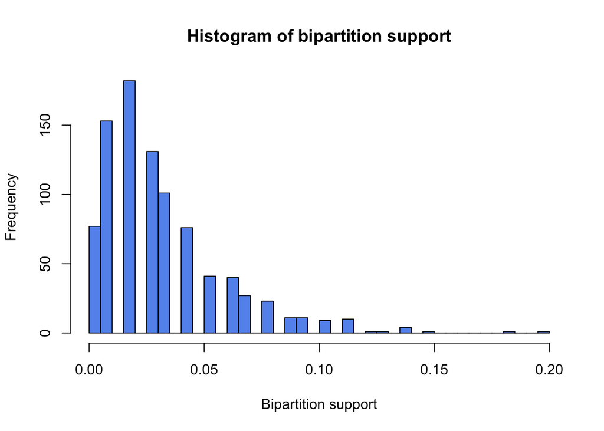

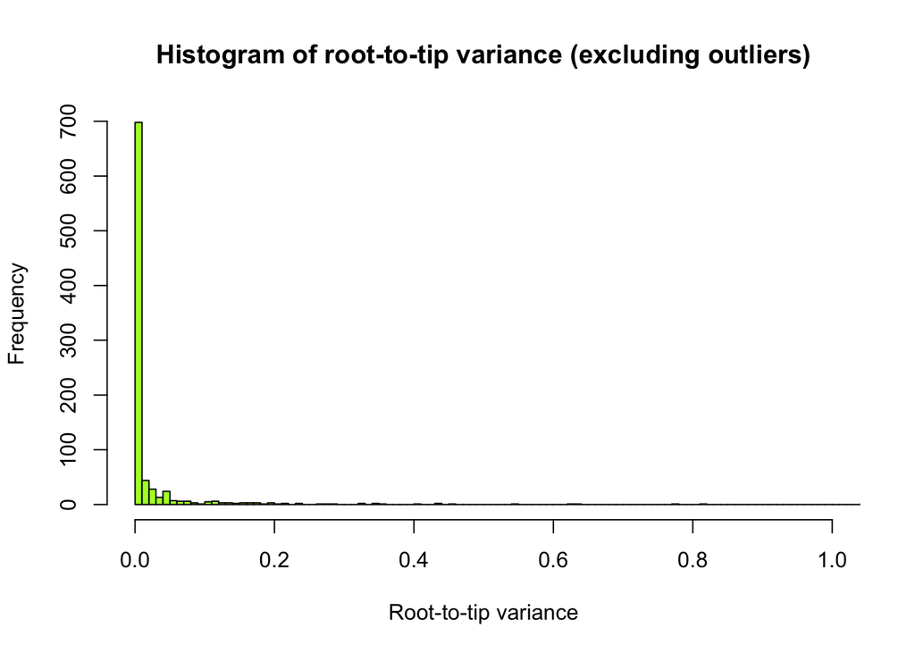

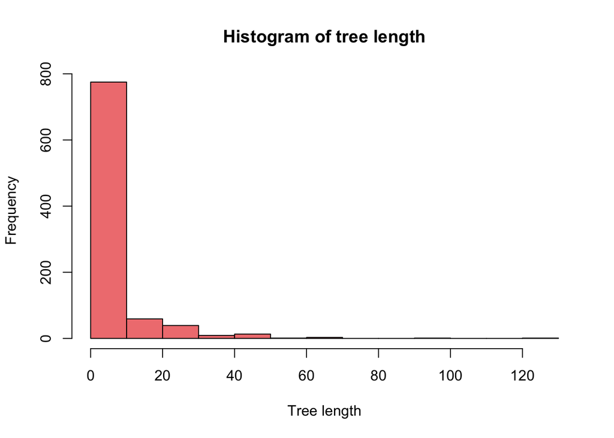

### Phase 4: get_good_genes

In order of descending priority: bipartition support, root-to-tip variance, tree length

```
python src/get_good_genes.py comb-chunks75-filtered --max 3 --order 3,1,2 --outf gg-chunks75-312
```

```
name root-to-tip_var treelength bipartition
uce-157_chunk_7.tre 0.163848 13.508 0.198275862069
uce-126_chunk_3.tre 0.101031 13.9331 0.181034482759
uce-323_chunk_2.tre 0.459664 40.9379 0.146551724138
```

In order of descending priority: bipartition support, tree length, root-to-tip variance

```
python src/get_good_genes.py comb-chunks75-filtered --max 3 --order 3,2,1 --outf gg-chunks75-321
```

```
name root-to-tip_var treelength bipartition
uce-157_chunk_7.tre 0.163848 13.508 0.198275862069
uce-126_chunk_3.tre 0.101031 13.9331 0.181034482759
uce-323_chunk_2.tre 0.459664 40.9379 0.146551724138
```

In order of descending priority: tree length, root-to-tip variance, bipartition support

```
python src/get_good_genes.py comb-chunks75-filtered --max 3 --order 2,1,3 --outf gg-chunks75-213
```

```
name root-to-tip_var treelength bipartition
uce-815_chunk_8.tre 0.0 0.0202802 0.0
uce-359_chunk_7.tre 0.0 0.0203467 0.00862068965517
uce-160_chunk_3.tre 0.0 0.0204413 0.0
```

In order of descending priority: tree length, bipartition support, root-to-tip variance

```
python src/get_good_genes.py comb-chunks75-filtered --max 3 --order 2,3,1 --outf gg-chunks75-231
```

```
name root-to-tip_var treelength bipartition
uce-815_chunk_8.tre 0.0 0.0202802 0.0
uce-359_chunk_7.tre 0.0 0.0203467 0.00862068965517
uce-160_chunk_3.tre 0.0 0.0204413 0.0
```

In order of descending priority: root-to-tip variance, tree length, bipartition support

```
python src/get_good_genes.py comb-chunks75-filtered --max 3 --order 1,2,3 --outf gg-chunks75-123
```

```
name root-to-tip_var treelength bipartition
uce-815_chunk_8.tre 0.0 0.0202802 0.0
uce-359_chunk_7.tre 0.0 0.0203467 0.00862068965517
uce-160_chunk_3.tre 0.0 0.0204413 0.0
```

In order of descending priority: root-to-tip variance, bipartition support, tree length

```
python src/get_good_genes.py comb-chunks75-filtered --max 3 --order 1,3,2 --outf gg-chunks75-132
```

```
name root-to-tip_var treelength bipartition
uce-200_chunk_2.tre 0.0 0.0317025 0.0344827586207
uce-129_chunk_5.tre 0.0 0.0211935 0.0258620689655
uce-1062_chunk_5.tre 0.0 0.113443 0.0258620689655
```

## 50-bp chunks: SH-like of 90% or above

(The first three steps were identical to those described above.)

### Phase 1: get_var_length

```
python src/get_var_length.py /Users/David/Grive/Alfaro_Lab/Acanthomorpha/sate-gblocks-clean-min-114-taxa/Chunks_90/ --flend .tre --outf var-chunks90 --outg alepisaurus_ferox,ceratoscopelus_warmingii
```

### Phase 2: get_bp_genetrees

```
python src/get_bp_genetrees.py /Users/David/Grive/Alfaro_Lab/Acanthomorpha/sate-gblocks-clean-min-114-taxa/Chunks_90/ /Users/David/Grive/Alfaro_Lab/Acanthomorpha/12_no_outgroups_scheme_3.tre --flend .tre --outf bp-chunks90
```

### Phase 3: combine_results

```
python src/combine_results.py var-chunks90 bp-chunks90 --outf comb-chunks90
```

(Delete the lines with NAs)

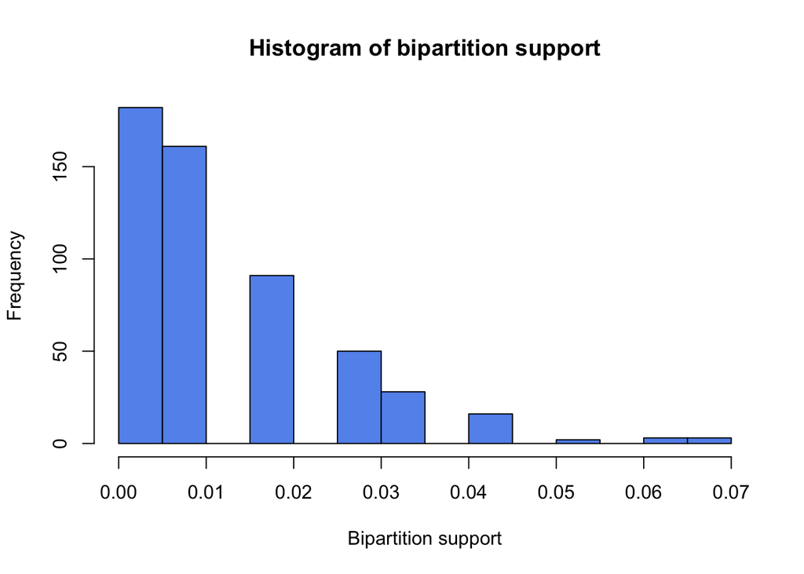

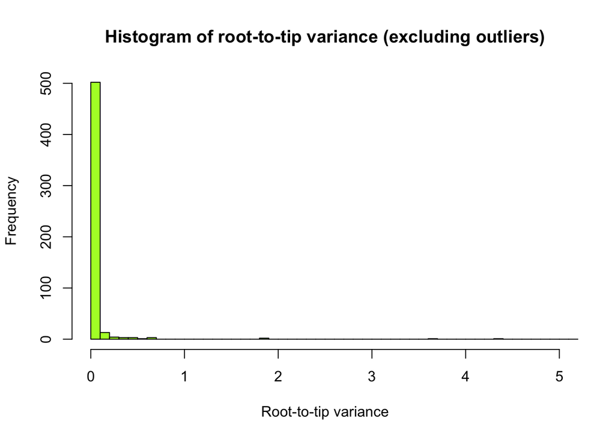

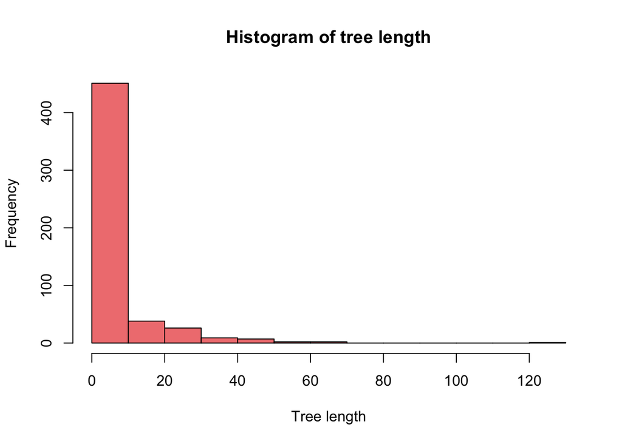

### Phase 4: get_good_genes

In order of descending priority: bipartition support, root-to-tip variance, tree length

```
python src/get_good_genes.py comb-chunks90-filtered --max 3 --order 3,1,2 --outf gg-chunks90-312
```

```
name root-to-tip_var treelength bipartition
uce-1317_chunk_8.tre 0.0166339 15.2225 0.0689655172414
uce-120_chunk_6.tre 0.187599 4.6936 0.0689655172414
uce-323_chunk_2.tre 0.325194 35.4206 0.0689655172414
```

In order of descending priority: bipartition support, tree length, root-to-tip variance

```
python src/get_good_genes.py comb-chunks90-filtered --max 3 --order 3,2,1 --outf gg-chunks90-321
```

```
name root-to-tip_var treelength bipartition
uce-120_chunk_6.tre 0.187599 4.6936 0.0689655172414
uce-1317_chunk_8.tre 0.0166339 15.2225 0.0689655172414
uce-323_chunk_2.tre 0.325194 35.4206 0.0689655172414
```

In order of descending priority: tree length, root-to-tip variance, bipartition support

```
python src/get_good_genes.py comb-chunks90-filtered --max 3 --order 2,1,3 --outf gg-chunks90-213
```

```
name root-to-tip_var treelength bipartition
uce-537_chunk_3.tre 0.0 8.71304e-07 0.00862068965517
uce-84_chunk_5.tre 0.0 9.84452e-07 0.0172413793103
uce-739_chunk_2.tre 0.0 2.2254e-06 0.0344827586207
```

In order of descending priority: tree length, bipartition support, root-to-tip variance

```
python src/get_good_genes.py comb-chunks90-filtered --max 3 --order 2,3,1 --outf gg-chunks90-231
```

```
name root-to-tip_var treelength bipartition
uce-537_chunk_3.tre 0.0 8.71304e-07 0.00862068965517
uce-84_chunk_5.tre 0.0 9.84452e-07 0.0172413793103
uce-739_chunk_2.tre 0.0 2.2254e-06 0.0344827586207
```

In order of descending priority: root-to-tip variance, tree length, bipartition support

```
python src/get_good_genes.py comb-chunks90-filtered --max 3 --order 1,2,3 --outf gg-chunks90-123
```

```
name root-to-tip_var treelength bipartition
uce-537_chunk_3.tre 0.0 8.71304e-07 0.00862068965517
uce-84_chunk_5.tre 0.0 9.84452e-07 0.0172413793103
uce-739_chunk_2.tre 0.0 2.2254e-06 0.0344827586207
```

In order of descending priority: root-to-tip variance, bipartition support, tree length

```
python src/get_good_genes.py comb-chunks90-filtered --max 3 --order 1,3,2 --outf gg-chunks90-132
```

```
name root-to-tip_var treelength bipartition
uce-739_chunk_2.tre 0.0 2.2254e-06 0.0344827586207
uce-832_chunk_4.tre 0.0 1.05876 0.0258620689655
uce-84_chunk_5.tre 0.0 9.84452e-07 0.0172413793103
```